# Data_8_5_analyse

2025-10-16

### Inleiding

Om meer te weten te komen over de ontwikkeling van de mens, is onderzoek naar embryonale ontwikkeling van groot belang. Het is een complex proces waarbij het begrijpen van de vele moleculaire processen van groot belang is. Een modelsysteem wat hiervoor gebruikt kan worden is de muis. De muis heeft een grote evolutionaire verwantschap aan de mens. Binnen drie weken kan een embryo zich ontwikkelen tot een zelfstand levende jonge muis. Dit bij elkaar maakt het een uitstekend modelsysteem voor onderzoek naar embryonale ontwikkeling.

Een van de onderzoeken wat gedaan kan worden is naar long non-coding RNA (lncRNA). lncRNA zijn stukjes RNA die groter zijn dan 200 basisparen. Ze coderen niet voor eiwitten, zoals messenger RNA (mRNA) dit doet, maar zorgen wel voor veel andere processen binnen de cel. lncRNA lijkt een essentiële rol te spelen bij het reguleren van de celprofliferatie, celcyclus, differentiatie en apoptose. De lncRNA’s kunnen dienen ten eerste als signaalmoleculen. Ze worden dan getranscripteerd na een omgevingsstimuli en dienen als biomarker voor ander biologische processen. Ten tweede als decoymoleculen waarbij ze binden aan bijvoorbeeld andere transcriptie regulatoren waardoor deze geremd worden. Ten derde kunnen lncRNA’s eiwitten begeleiden naar locaties. Hierdoor kan gen expressie gereguleerd worden. Ten vierde dienen ze als scaffold moleculen waarbij ze verschillende moleculen kunnen samenbinden tot een groot macromolecuul. En als laatste kunnen lncRNA’s kleine microRNA’s (mRNA) weghalen waardoor transcriptie van het stuk mRNA toeneemt waar de mRNA gebonden zat. De verschillende functies worden ook uitgevoerd tijdens de embryogenese. Hier zorgen ze voor regulatie van genexpressie, maar ook bijvoorbeeld voor regulatie van pluripotente stam cellen.

Bij dit onderzoek zal er pipeline gemaakt worden voor de verwerking van de data waarbij de lncRNA’s er uitgefilterd worden. Door alleen te kijken naar de lncRNA en niet de andere RNA data, kunnen er wellicht markers gevonden worden die normaal uit de data weg gefilterd worden. De analyse zal uitgevoerd worden met Seurat. Met dit progamma kan de data gefilterd op de kwaliteit van de cellen, data genormaliseerd worden, feature selectie (lncRNA selectie), principal component analysis en uiteindelijk het clusteren van de genen. De data kan makkelijk gevisualiseerd worden en hopelijk kan hiermee ook nieuwe lncRNA markers geanalyseerd worden die betrokken zijn bij de embryogenese.

### Doel

Hoofdvraag: Kan een lncRNA-gerichte single-cell RNA-seq pipeline nieuwe, cell-type-specifieke markers identificeren tijdens de embryogenese? Deelvraag: Welke lncRNA’s komen uit de gecombineerde dataset?

### Hypothese

Er wordt verwacht dat er lncRNA markers worden geidentifiseerd uit de dataset die betrekking hebben tot de embryogenese. Er wordt verwacht dat dit minder marksers zijn dan wanneer er een lncRNA only analyse wordt gedaan.

## Data analyse met Seurat

In Seurat worden de volgende stappen doorlopen - inladen van de data - QC van de data en selecteren van de cellen voor vervolganalyse - normaliseren van de data en het schalen van de data - Dimensionaliteitsreductie met PCA - clusteren van de genen - Visualisatie van resultaten in overzichtelijke plots - Identificatie van markers die specifieke celtypen onderscheiden

### het inladen van de data

De data wordt inladen als een object. De data uit het onderzoek is al gedownload op de server. Dit is te vinden onder het volgende pad: ‘/home/data/projecticum/splicing/data/’. Omdat het om hele grote bestanden gaat is er voor gekozen om de data niet nog in het eigen project te zetten. Dit zou onnodig veel ruimte in beslag nemen.

De ruwe data van het onderzoek is te vinden bij de GEO website onder het volgende nummer: GSE176588.

### pre-procesing en QC van de data

Om de kwaliteit van de ruwe data te bekijken, wordt er o.a. gekeken naar het percentage van mitochondrial RNA. Dit is een maat voor de levensvatbaarheid van de cellen. Hoe hoger het percentage mitochondrial RNA, hoe slechter de levensvatbaarheid van de cel is. Bij de nFeature plot wordt er het totaal aantal features per cel weergeven. Bij de nCount_RNA plot wordt er gekeken naar het totaal aantal RNA moleculen per cel. Bij de percent.mt plot wordt er gekeken wat het precentage mitochondiraal RNA per cel is.

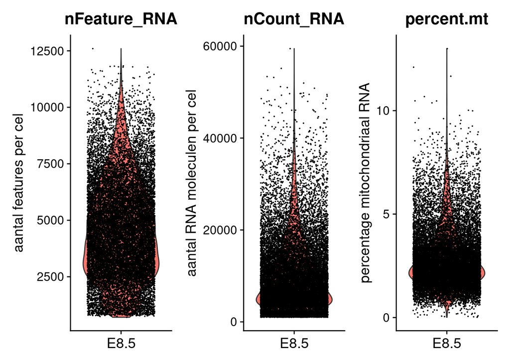

In de afbeeldingen is te zien dat veel cellen veel features hebben. Dit kan te maken hebben met het celtype. cellen uit de embryomale ontwikkeling zijn actief aan het ontwikkelen en produceren veel verschillende genen. Het percentage mitochondiraal RNA is niet heel hoog bij de meeste cellen. Een hoog percentage kan duiden op slechte kwaliteit van de cellen. Het grootste gedeelte van de data heeft een goede kwaliteit. Cellen met een hoger pecentage mitochondriaal RNA dan 5 % worden eruit gefilterd. Om wat meer te kunnen zeggen over de kwaliteit van de cellen, kunnen de verschillende waardes ook tegenover elkaar gezet worden in een FeaturesScatter plot. Hieronder zijn twee van deze plotten zichtbaar waarbij de nCount_RNA tegenover de percent.mt is gezet. In de tweede grafiek zijn de nCount_RNA gezet tegenover de nFeature_RNA.

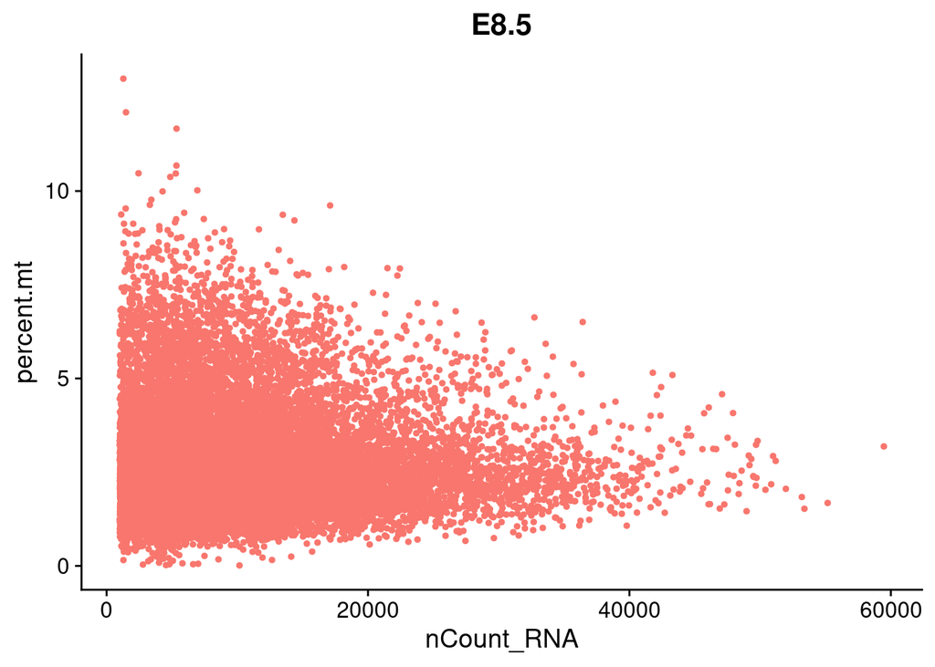

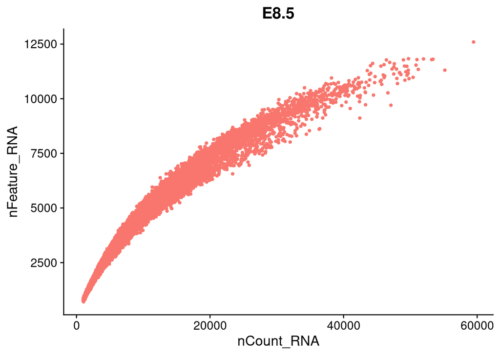

Bij de grafiek waarbij nCount_RNA tegenover de percent.mt is gezet, wordt er gekeken of er een correlatie is tussen het aantal RNA moleculen in een cel en de hoeveelheid mitochondriaal RNA. Wanneer er cellen zijn met veel RNA moleculen en een hoog percentage mitochondriaal RNA, kan dit betekenen dat er meercellige druppels zijn geweest bij de isolatie. Dit kan dus zorgen voor verhoogde waardes. Bij de data hierboven is dit niet te zien. Er zijn wel cellen te zien met een lage count met wel hogere mitochonriale waarde. Dit kan beteken op slechte kwaliteit van de cellen. Dit is ook te verwachten en wordt er in de volgende stappen uitgefilterd.

### feature selectie van de data

De data moet geselecteerd worden op genen die de meeste variabiliteit tonen. Dit zorgt ervoor dat bij verdere analyses er gefocused wordt op genen die variabel van elkaar zijn. Genen die niet variabel zijn kunnen in verdere analyse juist veel ruis veroorzaken. Deze functie staat standaard ingesteld op 2000 features per dataset. De data wordt weergeven in een VariableFeaturePlot. In de plot staan de top 10 meest variabele genen weergeven. De labels geven de namen van de genen aan in het plot.

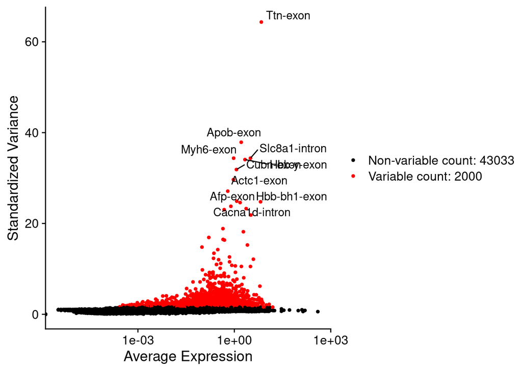

### schalen van de data

De functie zorgt ervoor dat de data vergelijkbaar wordt op de schaal en het gemiddelde. Dit zorgt ervoor dat de data beter verwerkt wordt bij verdere analyse zoals bij de PCA. Hierdoor wordt voorkomen dat genen die veel tot expressie komen niet overheersen. De schaal is ten opzichte van 0 en de genen kunnen positief of negatief zijn.

De data kan ook gevisualiseerd worden in een 2D plot. Hierin worden de eerste twee dimenties weergeven. De top genen worden weergeven.

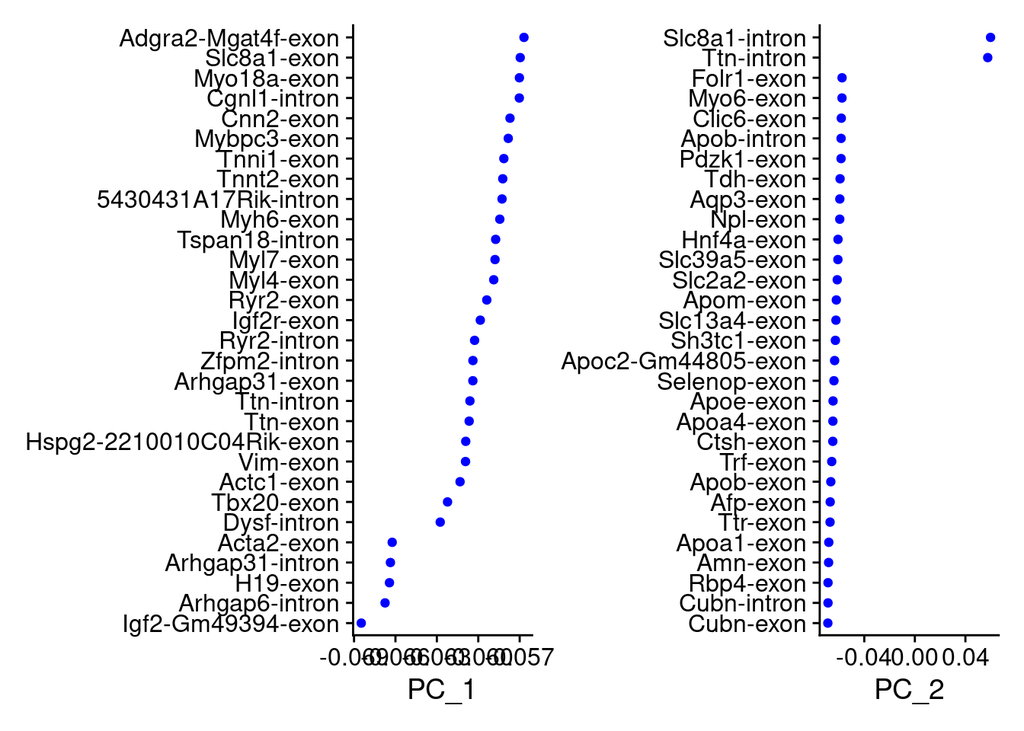

De data kan ook worden weergeven in een dimplot. Een dimplot is een plot waar alle cellen zijn eigen puntje hebben. PC1 en PC2 zijn tegenover elkaar uitgezet.

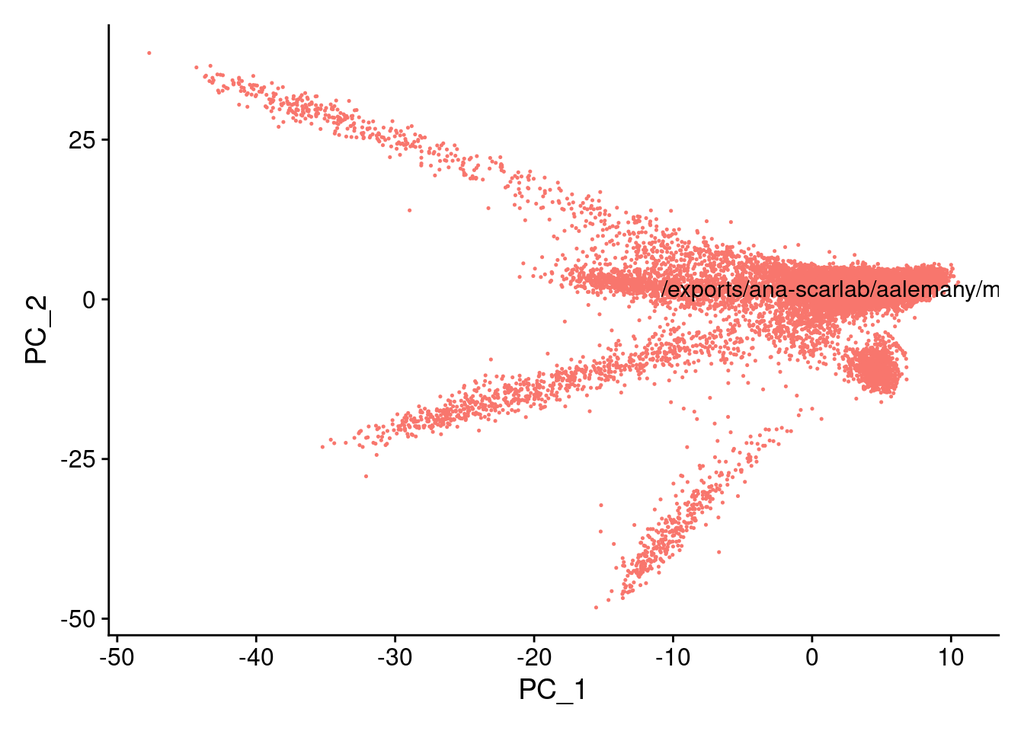

Een heatmap wordt gebruikt om te kijken welke onderdelen de grootste variatie van elkaar hebben. Dit kan ook gebruikt worden om te bepalen welke PC’s er meegenomen worden voor verdere analyse downstream. Door cellen op een getal in te stellen, worden de meest extreme cellen aan beide uiteinden van het spectrum weergegeven, wat het plotten van grote datasets aanzienlijk versnelt.

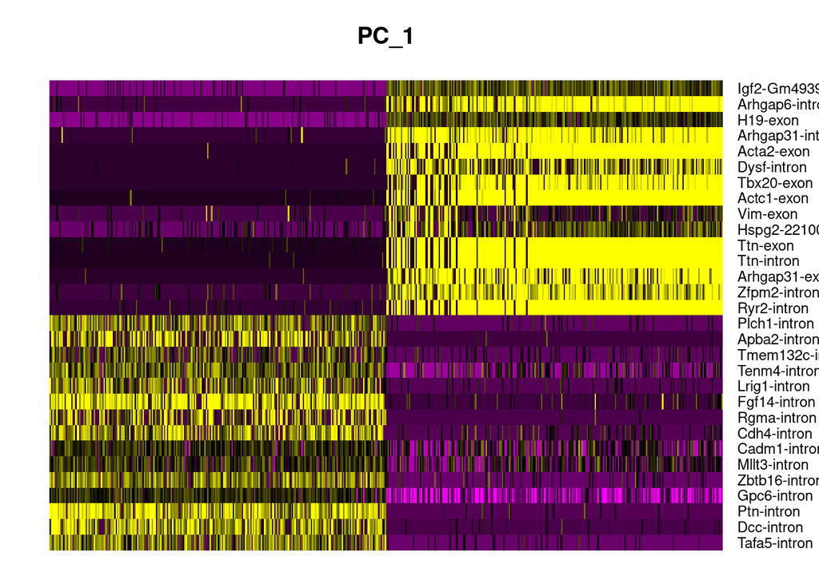

Clusters worden gebaseerd op de PCA waardes. Dit zijn correlaties tussen cellen die met de genexpressie op elkaar lijken. om te bepalen hoeveel van de PC’s we mee nemen wordt er een ElbowPlot van de PC’s gemaakt. In de plot wordt weergeven hoeveel variatie de PC’s bezitten.

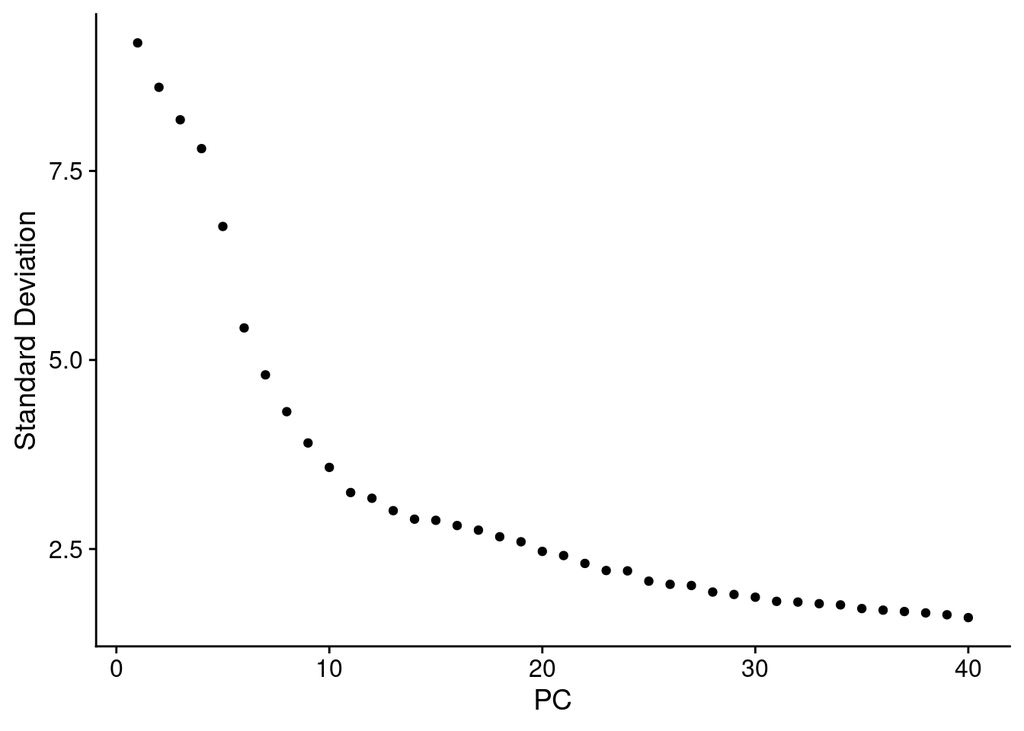

Aan de hand van de grafiek is er voor gekozen om de eerste 10 PC’s mee te nemen met de verdere dataverwerking. De data moet worden geclusterd. Voor het maken van de clusters moet er eerst bekeken worden wat de ruimte moet zijn tussen de verschillende cellen

```
## Modularity Optimizer version 1.3.0 by Ludo Waltman and Nees Jan van Eck
##
## Number of nodes: 14817
## Number of edges: 507269
##
## Running Louvain algorithm...
## Maximum modularity in 10 random starts: 0.9115
## Number of communities: 28
## Elapsed time: 1 seconds
```

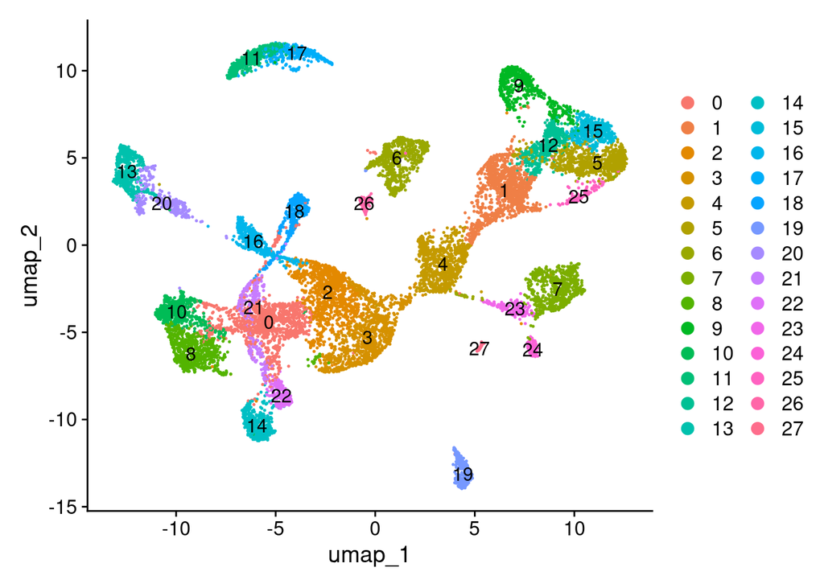

Nu de data uitgezet is in clusters kan er ook gekeken worden of de verschillende clusters ook unieke biomarkers hebben.